# Chapter 3 In-Class R Demo: Moving-Average Models

## Demo Goal

You will see that an MA model has short memory because only recent white noise terms matter.

Reference anchor: MA processes, invertibility intuition, and ACF cut-off behaviour.

```r
set.seed(311)
par(mfrow = c(1, 1))
```

## 1. Manual MA(1)

We simulate $X_t = \epsilon_t - \theta\epsilon_{t-1}$ with $\theta = 0.7$, written with a minus sign as in the notes.

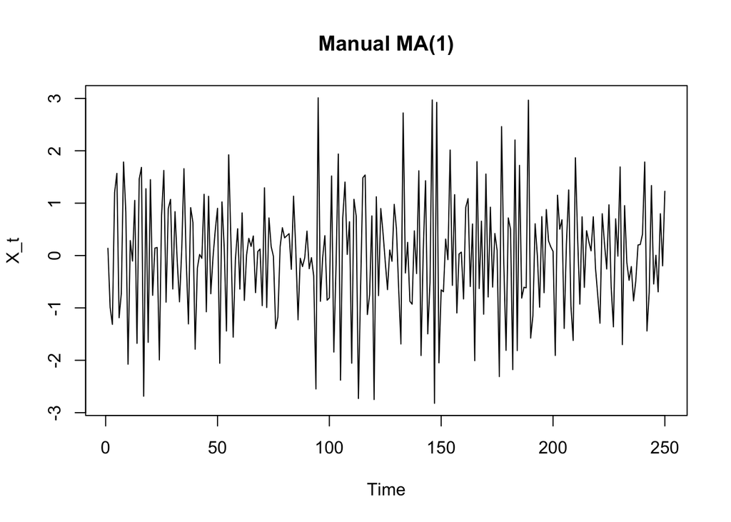

```r
n <- 250
theta <- 0.7
eps <- rnorm(n + 1)
x <- eps[2:(n + 1)] - theta * eps[1:n]

plot.ts(x, main = "Manual MA(1)", ylab = "X_t")
```

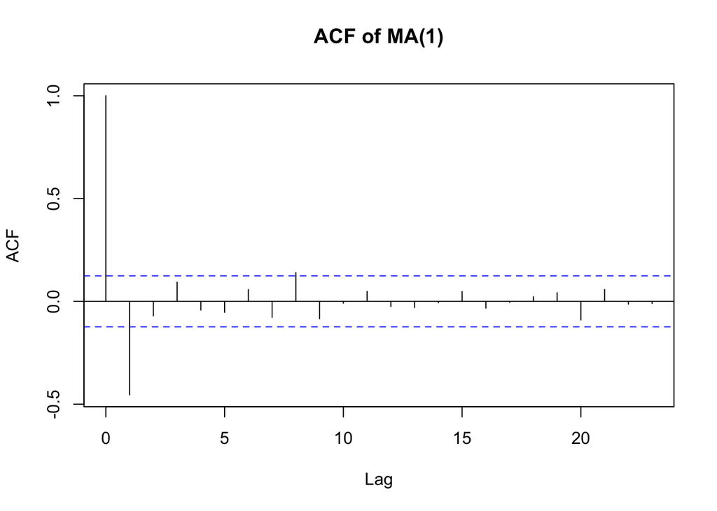

```r
acf(x, main = "ACF of MA(1)")
```

Questions:

- Why does the ACF cut off after lag 1?
- What does this say about memory?

## 2. Try Different MA Coefficients

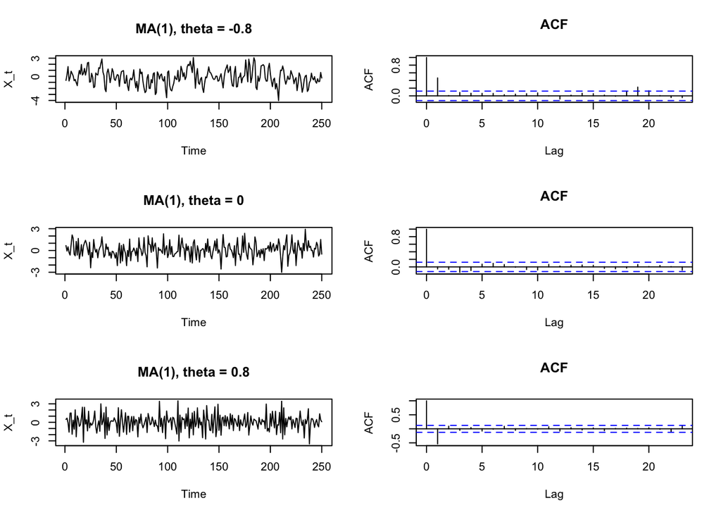

```r
theta_values <- c(-0.8, 0.0, 0.8)
par(mfrow = c(3, 2))
for (theta in theta_values) {
  eps <- rnorm(n + 1)
  x <- eps[2:(n + 1)] - theta * eps[1:n]
  plot.ts(x, main = paste("MA(1), theta =", theta), ylab = "X_t")
  acf(x, main = "ACF")
}
```

```r
par(mfrow = c(1, 1))
```

Questions:

- How does the sign of $\theta$ affect the lag-1 correlation? Compare with $\rho_1 = -\theta/(1 + \theta^2)$.

## 3. Fit an MA(1)

R writes the MA term with a plus sign, so $\theta = 0.6$ is entered as `ma = -0.6`, and the reported `ma1` estimates $-\theta$.

```r
x <- arima.sim(model = list(ma = -0.6), n = 250)   # theta = 0.6
fit <- arima(x, order = c(0, 0, 1))
fit
```

```
##
## Call:
## arima(x = x, order = c(0, 0, 1))
##
## Coefficients:
##           ma1  intercept
##       -0.5787     0.0231
## s.e.   0.0613     0.0244
##
## sigma^2 estimated as 0.8294:  log likelihood = -331.56,  aic = 669.12
```

```r
-coef(fit)["ma1"]                 # theta_hat in our convention
```

```
##       ma1
## 0.5786775
```

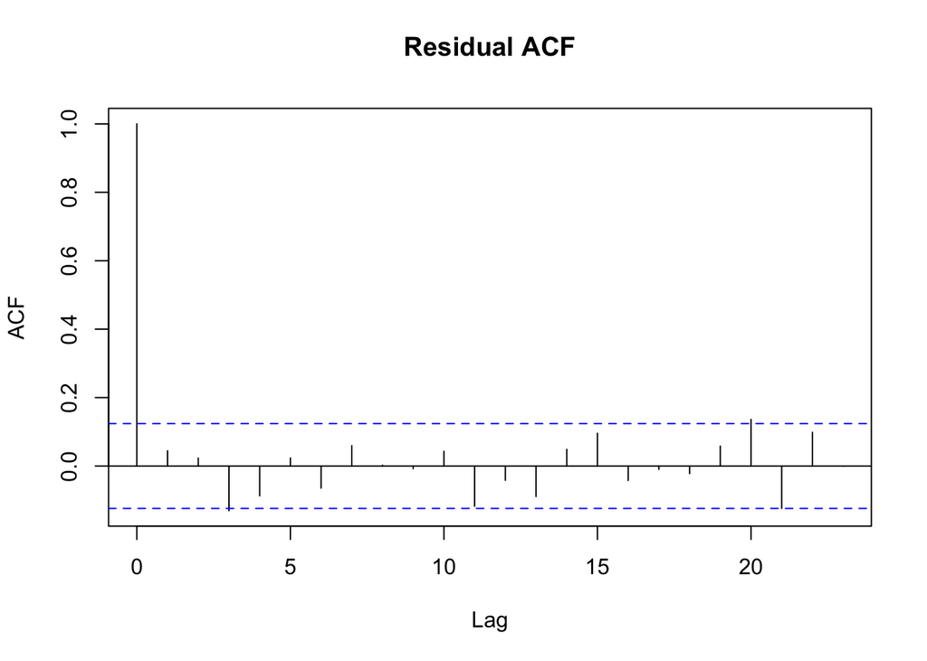

```r
acf(residuals(fit), main = "Residual ACF")
```

```r
Box.test(residuals(fit), lag = 12, type = "Ljung-Box", fitdf = 1)
```

```
##
##  Box-Ljung test
##
## data:  residuals(fit)
## X-squared = 13.674, df = 11, p-value = 0.2516
```

```r
c(MA1 = AIC(fit), MA2 = AIC(arima(x, order = c(0, 0, 2))))
```

```
##      MA1      MA2
## 669.1199 669.7166
```

Questions:

- Is $\hat\theta$ close to $0.6$? Why does `ma1` have the opposite sign?
- Why is `fitdf = 1`, and what does the Ljung–Box p-value say?
- Which model has the smaller AIC?

Try it yourself:

- Simulate an MA(2), then fit MA(1).
- What happens to the residual ACF?

## 4. Theoretical ACF and MA Bounds: MA(2)

The MA(2) of the notes, $X_t = \epsilon_t - 0.5\epsilon_{t-1} - 0.2\epsilon_{t-2}$. `ARMAacf()` gives the theoretical ACF (red points); `ci.type = "ma"` draws the wider bounds for judging an MA cut-off.

```r
theta2 <- c(0.5, 0.2)
x2 <- arima.sim(model = list(ma = -theta2), n = 250)
round(ARMAacf(ma = -theta2, lag.max = 4), 3)
```

```
##      0      1      2      3      4
##  1.000 -0.310 -0.155  0.000  0.000
```

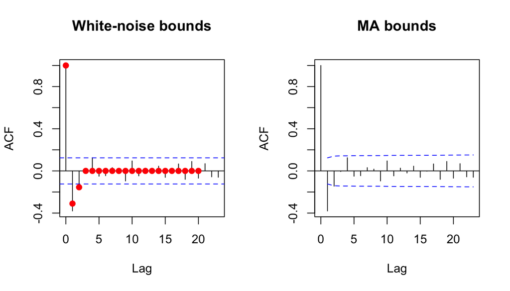

```r
par(mfrow = c(1, 2))
acf(x2, main = "White-noise bounds")
points(0:20, ARMAacf(ma = -theta2, lag.max = 20), col = "red", pch = 19)
acf(x2, ci.type = "ma", main = "MA bounds")
```

```r
par(mfrow = c(1, 1))
```

Questions:

- Where does the theoretical ACF cut off? Does the sample ACF agree?
- Why do the MA bounds widen with the lag?